# SOX2 Copy Number Variation and TP53 Mutation: Fisher’s Exact Test Analysis

Siber Gunes Celik

## Abstract

This project investigates the association between SOX2 copy number variation and TP53 mutation status across various cancer types using Fisher’s Exact Test. Data was obtained from [cBioPortal](https://www.cbioportal.org), and results are visualized and interpreted using R and relevant packages.

## Data Source

Data was downloaded from [cBioPortal](https://www.cbioportal.org), including patient IDs, SOX2 copy number variation, and TP53 mutation status.

## Data Preparation

The columns were cleaned and renamed for easier manipulation, and a contingency table was created to summarize the co-occurrence of the mutations.

```r
library(ggstatsplot)
library(RColorBrewer)
```

```r
# Load and prepare data
my_data <- read.delim('pancancer_combined.txt')
colnames(my_data) <- c('ID', 'TP53_status', 'SOX2_status')
head(my_data)
```

```
##                ID TP53_status SOX2_status
## 1 TCGA-AB-2989-03 No mutation     Diploid
## 2 TCGA-AB-3008-03 No mutation     Diploid
## 3 TCGA-AB-2863-03 No mutation     Diploid
## 4 TCGA-AB-2844-03 No mutation     Diploid
## 5 TCGA-AB-2955-03 No mutation     Diploid
## 6 TCGA-AB-2897-03 No mutation     Diploid
```

## Statistical Test

We used Fisher’s Exact Test to assess the association between SOX2 copy number gain and TP53 mutation status. Visualizations include mosaic plots and bar charts.

```r
# Define the attributes of interest
atr1 <- "Missense"
atr2 <- "Gain"

# Subsetting data to generate contingency table
Gene1atr1 <- subset(my_data, subset= TP53_status == atr1)
Gene2atr2 <- subset(my_data, subset = SOX2_status == atr2)

Cont1 <- subset(Gene1atr1, subset = SOX2_status == atr2)
Cont2 <- subset(Gene1atr1, subset = SOX2_status != atr2)
Cont3 <- subset(Gene2atr2, subset = TP53_status != atr1)
Cont4 <- subset(my_data, subset = TP53_status != atr1)
Cont4 <- subset(Cont4, subset = SOX2_status != atr2)

# Create contingency table
dat_table_2 <- data.frame(
  "atr1_present" = c(length(Cont1$ID), length(Cont3$ID)),
  "atr1_absence" = c(length(Cont2$ID), length(Cont4$ID)),
  row.names = c("atr2_present", "atr2_absence"),
  stringsAsFactors = FALSE
)
colnames(dat_table_2) <- c("atr1_present", "atr1_absence")
dat_table_2
```

```
##              atr1_present atr1_absence
## atr2_present          969         1378
## atr2_absence         1855         6510
```

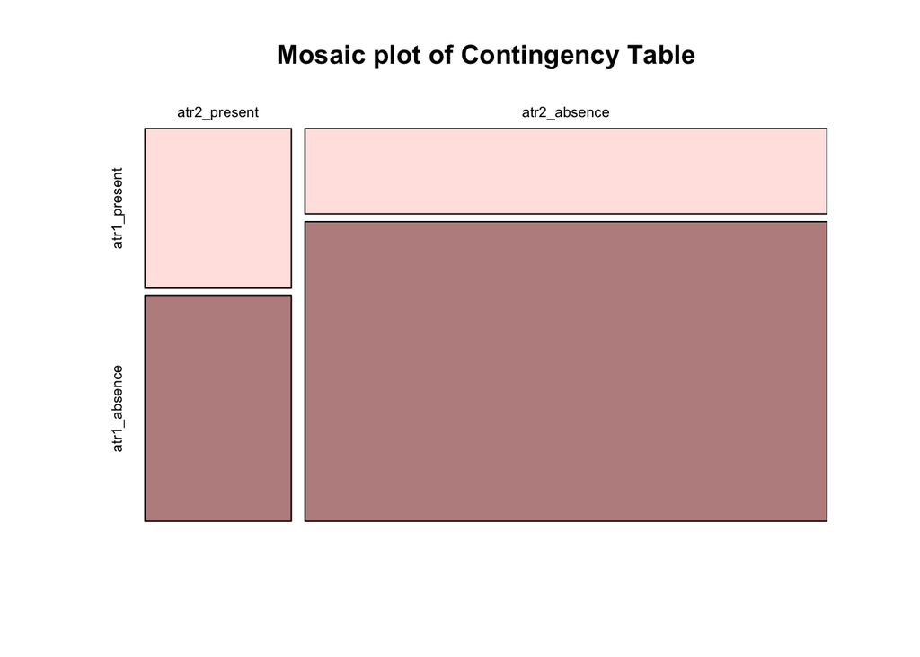

```r
# Contingency Table Visualization
mosaicplot(dat_table_2,
           main = "Mosaic plot of Contingency Table",
           color = c('#FFE4E1', '#BC8F8F'),
           border = TRUE
)
```

```r
# Fisher`s Exact Test

test_2 <- fisher.test(dat_table_2)
test_2
```

```
##
##  Fisher's Exact Test for Count Data
##
## data:  dat_table_2
## p-value < 2.2e-16
## alternative hypothesis: true odds ratio is not equal to 1
## 95 percent confidence interval:
##  2.236706 2.722133
## sample estimates:
## odds ratio
##   2.467412
```

## Results

Fisher’s Exact Test yielded a p-value < 0.001 and an odds ratio of 2.47, suggesting a statistically significant association between SOX2 gain and TP53 mutation in the dataset.

```r
# Create a transposed data frame for ggbarstats plot
x_2 <- c()
for (row in rownames(dat_table_2)) {
  for (col in colnames(dat_table_2)) {
    x_2 <- rbind(x_2, matrix(rep(c(row, col), dat_table_2[row, col]), ncol = 2, byrow = TRUE))
  }
}
df_2 <- as.data.frame(x_2)
colnames(df_2) <- c("gene1_atr1", "gene2_atr2")
head(df_2)
```

```
##     gene1_atr1   gene2_atr2
## 1 atr2_present atr1_present
## 2 atr2_present atr1_present
## 3 atr2_present atr1_present
## 4 atr2_present atr1_present
## 5 atr2_present atr1_present
## 6 atr2_present atr1_present
```

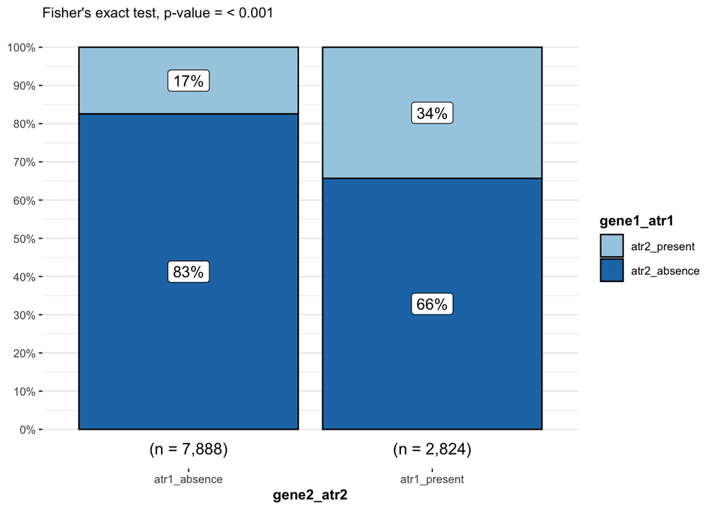

```r
# Plotting results with ggbarstats
test_2 <- fisher.test(table(df_2))
ggbarstats(
  df_2, gene1_atr1, gene2_atr2,
  results.subtitle = FALSE,
  package = "RColorBrewer",
  palette = "Paired",
  subtitle = paste0(
    "Fisher's exact test", ", p-value = ",
    ifelse(test_2$p.value < 0.001, "< 0.001", round(test_2$p.value, 3))
  )
)
```

## References

1: Oliveira, Natalia L., et al. “A discussion on significance indices for contingency tables under small sample sizes.” PLoS One 13.8 (2018): e0199102.

2: Kim, Hae-Young. “Statistical notes for clinical researchers: Chi-squared test and Fisher’s exact test.” Restorative Dentistry & Endodontics 42.2 (2017): 152-155.